# Perth rainfall analysis

## import and clean data

Import data and add some useful columns to our rain dataframe. This includes a boolean for whether it rained. Really just allows me to have more comprehensible code and saves me adding an extra label to my ggplots.

```r
#import libraries we want
suppressMessages(library(data.table))
suppressMessages(library(tidyverse))
suppressMessages(library(ggdark))
suppressMessages(library(patchwork))
#read data
NOAA_data <- fread("../data/3184544.csv")
#filter for usability
#turns out the data attributes are useless lol
NOAA_data <- NOAA_data %>% select(!ends_with("_ATTRIBUTES"))
#add month and day cols for easier group-by summaries later
NOAA_data <- NOAA_data %>%
  mutate(
    Year = format(DATE, "%Y") %>% as.numeric(),
    Month = month(DATE),
    Day = format(DATE, "%d") %>% as.numeric(),
    #bool for any rain
    did_rain = PRCP > 0,
    Month_name = month.name[Month] %>% fct_relevel(month.name)
  )
NOAA_data %>% head(2)
```

| STATION | NAME | LATITUDE | LONGITUDE | ELEVATION | DATE | PRCP | SNWD | TAVG | TMAX | TMIN | Year | Month | Day | did_rain | Month_name |
| --- | --- | --- | --- | --- | --- | --- | --- | --- | --- | --- | --- | --- | --- | --- | --- |
| ASN00009021 | PERTH AIRPORT, AS | -31.9275 | 115.9764 | 15.4 | 1944-05-01 | 0 | NA | NA | NA | NA | 1944 | 5 | 1 | FALSE | May |
| ASN00009021 | PERTH AIRPORT, AS | -31.9275 | 115.9764 | 15.4 | 1944-05-02 | 0 | NA | NA | NA | NA | 1944 | 5 | 2 | FALSE | May |

## data properties

We should take a quick look at how rainfall and temperature are distributed.

We can see that Precipitation is broadly exponentially distributed and that a vast majority of days have none to very little rain. A second graph shows that the pattern holds when 0 rain days are removed.

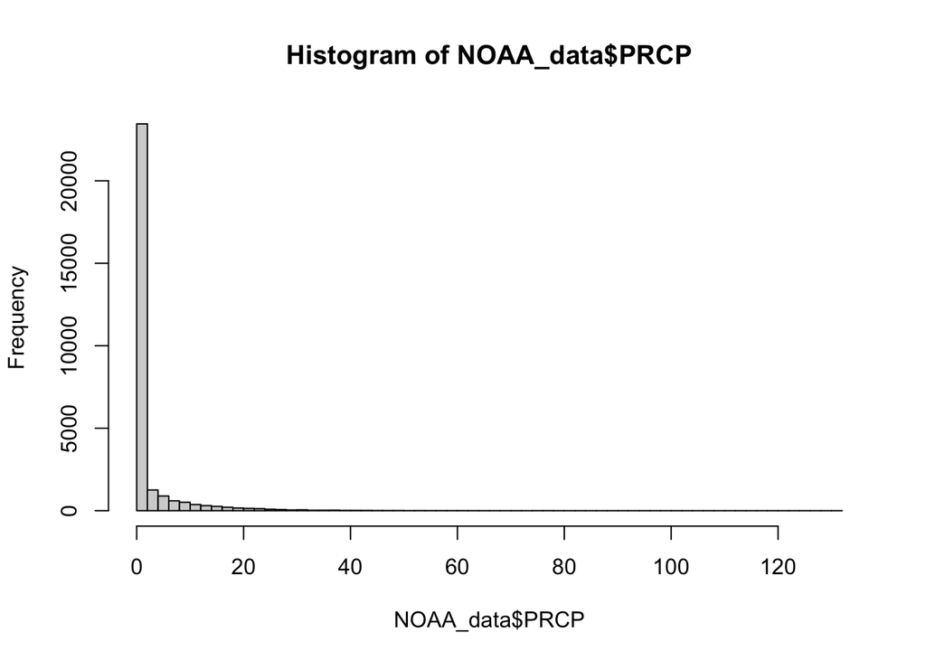

```r
#we can use hist() with custom breaks to get a good feel for data shape here
hist(NOAA_data$PRCP, breaks = 50)
```

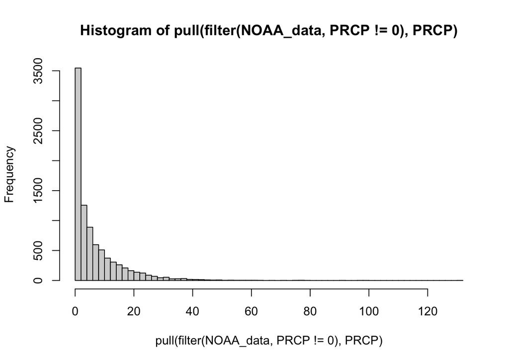

```r
#same thing, but remove no rain days
hist(pull(filter(NOAA_data, PRCP != 0), PRCP), breaks = 50)
```

Often, taking mean values of non normal data will result in data that tends to be normally distributed, and thus more tractable, data. To see if that held here, I calculated the mean rainfall for each `month, year` pair and plotted the histograms. Unfortunately this assumption does not hold here. My first impression, since rainfall is restricted to $x \ge 0$, is that each month is roughly following a chi squared distribution with a different parameter value (larger values of $k$). Interestingly, the graph helps illustrate the highly seasonal nature of rainfall in Perth which I will explore further below.

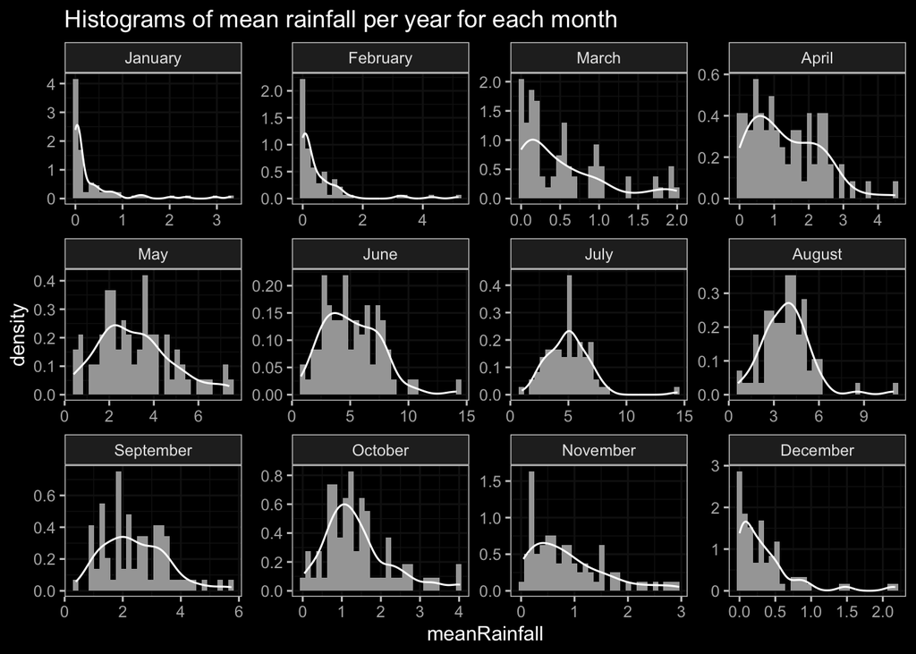

```r
NOAA_data %>%
    #get mean rainfall for month,year pairs
    group_by(Month_name, Year) %>%
    summarise(meanRainfall = mean(PRCP, na.rm = T)) %>%
    #plot
    ggplot(aes(meanRainfall, after_stat(density))) +
    geom_histogram() +
    geom_density() +
    #use facet_wrap to split plot by month
    facet_wrap(vars(Month_name), scales="free") +
    dark_theme_bw() +
    ggtitle("Histograms of mean rainfall per year for each month")
```

## Should you plan to go outside? Percent chance of any rain for Perth Airport

Probably the most striking feature of rain in Perth is just how seasonal it is. Looking at our first graph below we can see any given day in January has less than 10% chance of any rain while a given day in July has over 50% chance of any rain! The month to month change is dramatic, with the change in rainfall chance shifting rapidly in autumn and spring.

While summers are incredibly hot, and the UV index is dangerous, summer is a great time to plan outdoor activities that would be otherwise ruined by rain. In contrast, expect the opposite in winter.

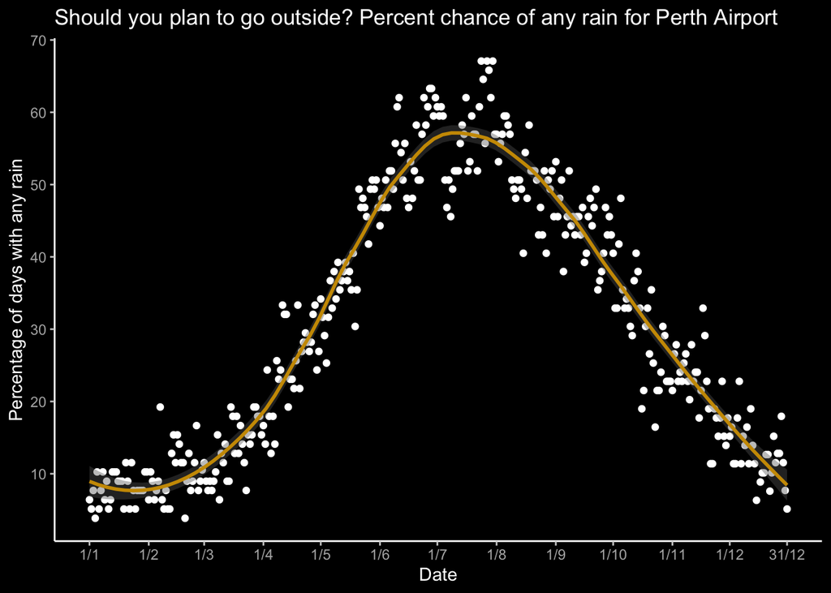

```r
#here we want a table where:
#each row = a day of the year
#and we want the probability of rainfall for that day
rainy_days <- NOAA_data %>%
    group_by(Month, Day) %>%
    summarise(
      number_of_rainy_days = sum(did_rain), days_observed = n()
    ) %>%
    #calculate proportion rainfall for a given day
    mutate(proportion_rained = number_of_rainy_days/days_observed)

#we add an index so we can count the days
rainy_days$index <- 1:length(rainy_days$Day)
#we add custom date strings for displaying on xlabel
rainy_days <- rainy_days %>%
  mutate(date_str = str_c(Day, Month, sep = "/"))
#and custom breaks for aesthetically showing these dates
custom_breaks = c(
    1,32,32+29,32+29+31,92+30,153,153+30,214,245,275,306,336,366
)
rainy_days %>%
    #multiply by 100 to get percentage
    ggplot(aes(index, proportion_rained*100)) +
    geom_point() +
    geom_smooth(span=0.5) +
    scale_y_continuous(breaks = seq(0,1,0.1)*100) +
    ylab("Percentage of days with any rain") +
    xlab("Date") +
    scale_x_continuous(
      breaks = custom_breaks, labels = rainy_days$date_str[custom_breaks]
    ) +
    ggtitle("Should you plan to go outside? Percent chance of any rain for Perth Airport") +
    dark_theme_classic()
```

## Changing rainfall with climate change

Perth is experiencing huge changes to it’s rainfall. We can illustrate this in our next plot that shows the total rainfall each year. As we can there is steady trend of decreasing rainfall year-on-year.

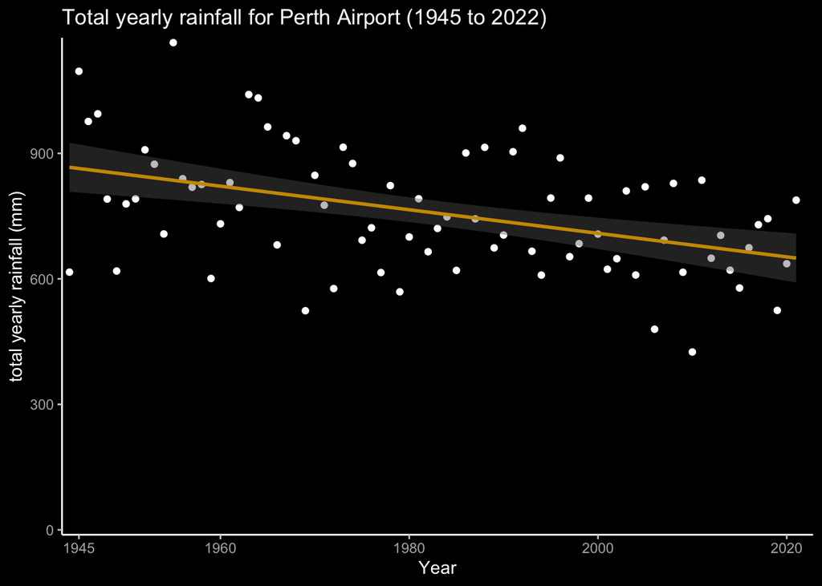

```r
rainfall_totals_yearly <- NOAA_data %>%
  group_by(Year) %>% summarise(total.Yearly.Rainfall = sum(PRCP))

rainfall_totals_yearly %>%
    ggplot(aes(Year, total.Yearly.Rainfall)) +
    geom_point() +
    geom_smooth(method="lm") +
    #use expand in scale param to remove annoying scale padding
    scale_x_continuous(breaks = c(1945,1960,1980,2000,2020), expand = c(0.01,0.01)) +
    #we use the below to remove some whitespace on this plot
    scale_y_continuous(
        expand = c(0.01,0.01),
        limits = c(0,max(rainfall_totals_yearly$total.Yearly.Rainfall))
    ) +
    ggtitle("Total yearly rainfall for Perth Airport (1945 to 2022)") +
    ylab("total yearly rainfall (mm)") +
    dark_theme_classic()
```

To get some specific numbers on this, we can run a linear regression and consider the intercept and slope. This will produce the same result as the line through the graph above, as `ggplot::geom_smooth(method="lm")` is using the same function as below (`lm()`).

```r
#to use our intercept we set 1944 to be "year zero"
base_year = 1944
#add a variable that uses 1944 as the base year
rainfall_totals_yearly <- rainfall_totals_yearly %>% mutate(Year_zeroed = Year-base_year)
#make a statistical model
rainfall_model_lm <- lm("total.Yearly.Rainfall ~ Year_zeroed" , data = rainfall_totals_yearly)
#print coefficients as a table
broom::tidy(summary(rainfall_model_lm))
```

| term | estimate | std.error | statistic | p.value |
| --- | --- | --- | --- | --- |
| (Intercept) | 866.645213 | 29.4485417 | 29.429139 | 2.713719e-43 |
| Year_zeroed | -2.817192 | 0.6602801 | -4.266661 | 5.655480e-05 |

We can see that in 1944, the average rainfall is 866mm (i.e. the intercept value) and that rainfall decreases at a rate of 2.8mm a year. In 2020 we would expect the rainfall to be 652.54 mm (the actual total was 636mm). That is a decrease of 211.29mm in just 75 years.

```r
#some years we want to predict rainfall for
Years = c(1950, 1970, 2020, 2040, 2080, 2100, 2200)
#use predict() to make predictions for Years and stuff this into a table
rainfallPredictionTable <- broom::tidy(
    predict(rainfall_model_lm, list(Year_zeroed=Years-base_year))
    )
#rename Years to Year
rainfallPredictionTable$Year <- Years
#and rename x to a meaningful name
rainfallPredictionTable$Predicted_Rainfall <- rainfallPredictionTable$x
#merge with rainfall yearly totals
rainfallPredictionTable <- merge(rainfallPredictionTable, rainfall_totals_yearly %>%
  filter(Year %in% Years) %>% select(Year, total.Yearly.Rainfall) %>%
    rename(Actual_rainfall = total.Yearly.Rainfall),
  all.x = TRUE)
#we can then take the difference of the predicted and actual rainfall totals for years with that data included
#and print the table to our notebook
rainfallPredictionTable %>%
  select(Year, Predicted_Rainfall, Actual_rainfall) %>%
  mutate(Difference = Actual_rainfall - Predicted_Rainfall)
```

| Year | Predicted_Rainfall | Actual_rainfall | Difference |
| --- | --- | --- | --- |
| 1950 | 849.7421 | 779.2 | -70.54206 |
| 1970 | 793.3982 | 847.5 | 54.10177 |
| 2020 | 652.5386 | 636.2 | -16.33865 |
| 2040 | 596.1948 | NA | NA |
| 2080 | 483.5071 | NA | NA |
| 2100 | 427.1633 | NA | NA |
| 2200 | 145.4441 | NA | NA |

## Changing rainfall, a deeper dive

This dataset is large enough for us to consider a deeper dive into Perth’s changing rainfall. We can explore a few questions with graphs and statistical models: 1. in which months is rainfall increasing or decreasing? 2. is the time of peak rainfall each year changing or constant?

## in which months is rainfall increasing or decreasing?

It is interesting to consider whether rainfall patterns are changing in the same way for all months and times of year. We can use linear models to approach this in two different ways:

1. We can run linear models of `Year = total_rainfall` separately for each month
2. We can use a single linear model with month as an interaction term, i.e `Year = total_rainfall * month`

### linear models for each month

While the latter is more elegant, the former is easier to illustrate on a graph. We can see the results on the graph below (“Perth rainfall monthly totals”). Here, we can see that the relationship between Total Rainfall and Year differs across the year. We can also plot in on the winter and summer months to get a better feel for this.

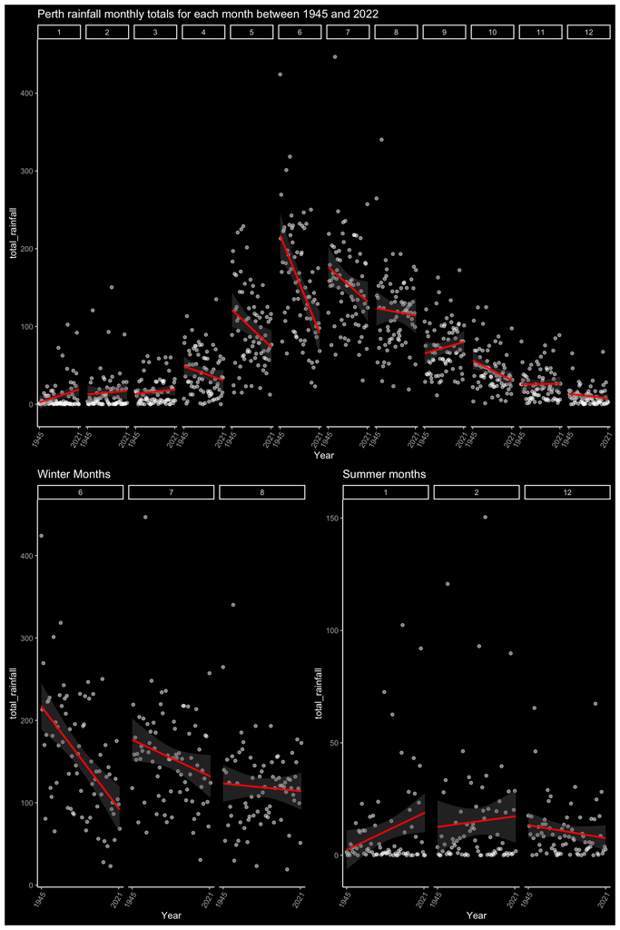

```r
#find min and max year
min_year = NOAA_data$Year %>% min
max_year = NOAA_data$Year %>% max
#rainfall totals by Year and Month
rainfall_totals <- NOAA_data %>%
    group_by(Year, Month) %>%
    summarise(total_rainfall = sum(PRCP))
#now we make a series of plots
#allmonths does scatter plots of rainfall vs day facetted by each month
allmonths <- rainfall_totals %>%
    filter(Year != 1944) %>%
    ggplot(aes(Year, total_rainfall)) +
    #facet by month
    facet_grid(cols=vars(Month)) +
    geom_point(alpha = 0.5) +
    #linear OLS for each month
    geom_smooth(method="lm", colour = "red") +
    scale_x_continuous(breaks = c(min_year+1, max_year-1)) +
    ggtitle("Perth rainfall monthly totals for each month between 1945 and 2022") +
    dark_theme_classic() +
    #we adjust labels to fit better here
    theme(axis.text.x=element_text(angle=60,hjust=1))
#winter and summer are the same plots but only for the summer and winter months,
#for illustration
winter <- rainfall_totals %>%
    filter(Year != 1944, Month %in% 6:8) %>%
    ggplot(aes(Year, total_rainfall)) +
    facet_grid(cols=vars(Month)) +
    geom_point(alpha = 0.5) +
    geom_smooth(method="lm", colour = "red") +
    scale_x_continuous(breaks = c(min_year+1, max_year-1)) +
    ggtitle("Winter Months") +
  dark_theme_classic() +
    theme(axis.text.x=element_text(angle=60,hjust=1))
summer <- rainfall_totals %>%
    filter(Year != 1944, Month %in% c(1:2,12)) %>%
    ggplot(aes(Year, total_rainfall)) +
    facet_grid(cols=vars(Month)) +
    geom_point(alpha = 0.5) +
    geom_smooth(method="lm", colour = "red") +
    scale_x_continuous(breaks = c(min_year+1, max_year-1)) +
    ggtitle("Summer months") +
  dark_theme_classic() +
    theme(axis.text.x=element_text(angle=60,hjust=1))
allmonths/(winter | summer)
```

Interestingly, the *rate of change*, as expressed by the absolute magnitude of the coefficient differs considerably between months. The winter months had by far the largest rates of change. Since the winter months have negative coefficients, we interpret this as saying that rainfall is decreasing in these months much faster than in the warmer months.

We can also see the summer months have very little estimated change in their year to year rainfall totals. But there are tentative, although non-significant, indications of increasing rainfall.

```r
#here we take linear models of total_rainfall ~ Year for each month
#to do this we group by Month and use dplyr::group_modify to perform lm() group-wise
models.year_vs_rainfall_per_month <- rainfall_totals %>%
    mutate(Year = Year - base_year) %>%
    group_by(Month) %>%
    #we use broom::tidy to stuff each month into a table that is
    #then smoothly returned as a df
    group_modify(~ broom::tidy(lm(total_rainfall ~ Year, data = .)))
#show the table after adding nominal and bonferroni filter variables
models.year_vs_rainfall_per_month %>%
  mutate(nominal_significant = p.value < 0.05) %>%
  mutate(passes_bonferroni = p.value < 0.05/12)
```

| Month | term | estimate | std.error | statistic | p.value | nominal_significant | passes_bonferroni |
| --- | --- | --- | --- | --- | --- | --- | --- |
| 1 | (Intercept) | 2.15028305 | 4.45102830 | 0.4830980 | 6.304149e-01 | FALSE | FALSE |
| 1 | Year | 0.21550728 | 0.09789773 | 2.2013512 | 3.074623e-02 | TRUE | FALSE |
| 2 | (Intercept) | 12.53216783 | 6.05201116 | 2.0707443 | 4.177850e-02 | TRUE | FALSE |
| 2 | Year | 0.06160042 | 0.13311040 | 0.4627770 | 6.448466e-01 | FALSE | FALSE |
| 3 | (Intercept) | 13.24432234 | 3.90474500 | 3.3918533 | 1.104613e-03 | TRUE | TRUE |
| 3 | Year | 0.07576854 | 0.08588255 | 0.8822343 | 3.804320e-01 | FALSE | FALSE |
| 4 | (Intercept) | 49.03339993 | 6.69087278 | 7.3284012 | 2.101445e-10 | TRUE | TRUE |
| 4 | Year | -0.23167971 | 0.14716178 | -1.5743199 | 1.195675e-01 | FALSE | FALSE |
| 5 | (Intercept) | 121.46648734 | 11.01656950 | 11.0257996 | 1.662561e-17 | TRUE | TRUE |
| 5 | Year | -0.61394109 | 0.24385119 | -2.5176875 | 1.388923e-02 | TRUE | FALSE |

[output cut: 14 more lines]

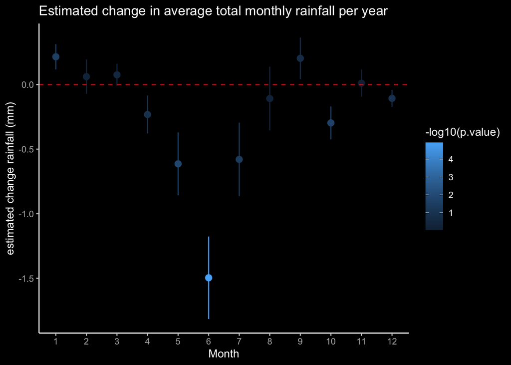

```r
#plot the coefficients with SE lines for each month
models.year_vs_rainfall_per_month %>%
    filter(term == "Year") %>%
    ggplot(aes(Month, estimate, ymin=estimate-std.error, ymax=estimate+std.error, colour = -log10(p.value))) +
    dark_theme_classic() +
    geom_point() +
    geom_pointrange() +
    #we add a line at zero to illustrate the positive and negative coefficients better
    geom_hline(yintercept = 0, linetype = 'dashed', alpha = 0.8, colour = "red") +
    ggtitle("Estimated change in average total monthly rainfall per year") +
    ylab("estimated change rainfall (mm)") +
    #custom label breaks to get month integers
    scale_x_continuous(breaks = 1:12)
```

### month as an interaction term

We can also briefly pause to see how using Month as an interaction term can robustly support the hypothesis that the year-on-year change in rainfall total is influenced by the month.

In order for this to work effectively we need to modify our Month variable so that it is either a `factor` or so that the winter months are the lowest or highest valued months.

While using month as a factor avoids any assumptions about months being in a specific order, it also dilutes our test by requiring each Month to act as it’s own variable.

Instead, we can reparameterise our Month variable so that summer months have larger absolute values and winter months have smaller absolute values. We do this by subtracting the Month integer by 6 and taking the absolute value of this, leaving us with 7 unique values from 0 and 6.

```r
#add year baselined at 1944 and Month integer centred on July
#these help with the linear model
rainfall_totals <- rainfall_totals %>%
  mutate(Year_zeroed = Year - base_year) %>%
  mutate(Month_reparam = abs(Month-6))
#generate a linear model
year.by.month.model <- lm(total_rainfall ~ Year_zeroed*Month_reparam, data=rainfall_totals)
#and return coefficients as a table to the notebook
broom::tidy(summary(year.by.month.model))
```

| term | estimate | std.error | statistic | p.value |
| --- | --- | --- | --- | --- |
| (Intercept) | 170.7174723 | 5.92802760 | 28.798360 | 3.259228e-131 |
| Year_zeroed | -0.8125700 | 0.13123821 | -6.191565 | 8.893170e-10 |
| Month_reparam | -32.5311964 | 1.70280007 | -19.104531 | 5.459100e-69 |
| Year_zeroed:Month_reparam | 0.1870996 | 0.03776676 | 4.954082 | 8.616787e-07 |

We can now run our model using rainfall totals for each month, year pair. The result shows approximately what we would expect; rainfall is estimated to be decreasing year-on-year while there is a very strong negative relationship between our reparamterised Month variable (i.e rainfall decreases with increasing values, which fits with summer (larger values) having very low rainfall). We can also see that our interaction term indicates a small, but statistically significant, interaction between Year and Month. The coefficient is positive, which supports the argument that rainfall is decreasing in winter while the relationship is weaker in the warmer months.

## is the time of peak rainfall each year changing or constant?

Another apparent trend in Perth’s weather pattern is that the period of peak rainfall is shifting to later in the year. Traditionally, June has been the month with the highest rainfall totals. But as we have seen above, June is experiencing a faster decline in rainfall with each year compared to any other month. This might lead us to think that another winter month might end up with greater rainfall in future years.

To test this in a visual way, we can inspect the rainfall difference for each year between pairs of months.

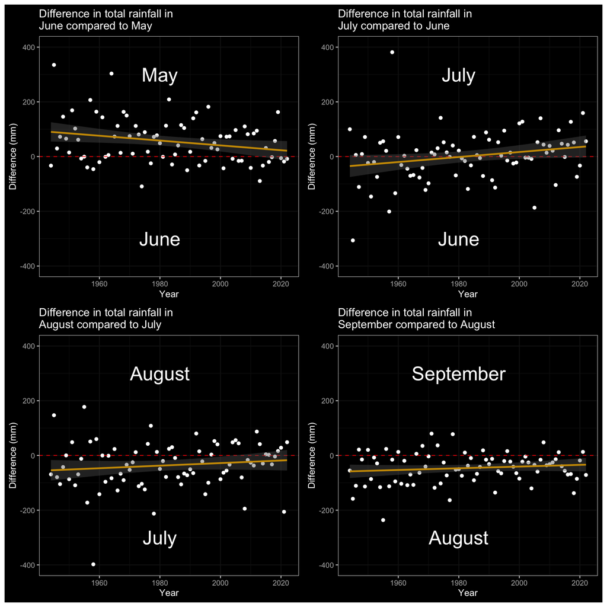

```r
#we generate a table that:
# 1. takes rainfall totals by year,month pairs
# 2. pivots wider to get each month's total rainfall as a column variable
# 3. subtract month variables from each other to get difference between months
rainfall_totals_bigger_month <- rainfall_totals %>%
    select(Year, Month, total_rainfall) %>%
    pivot_wider(names_from = c(Month), values_from = total_rainfall) %>%
    #do the subtraction here
    mutate(
        delta_6_5 = `6` - `5`,
        delta_7_6 = `7` - `6`,
        delta_8_7 = `8` - `7`,
        delta_9_8 = `9` - `8`,
    )
#then we generate plots for each month in turn
may <- rainfall_totals_bigger_month %>%
  ggplot(aes(Year, delta_6_5)) + geom_point() +
    #add a line at 0 i.e. no difference to highlight positive negative spread
    geom_hline(yintercept = 0, linetype = 'dashed', alpha = 0.8, colour = "red") +
    geom_smooth(method="glm") +
    ggtitle("Difference in total rainfall in\nJune compared to May") +
    ylab("Difference (mm)") + dark_theme_bw() + ylim(-400,400) +
    annotate("text", label = "May", x = 1980, y = 300, size = 8) +
    annotate("text", label = "June", x = 1980, y = -300, size = 8)
june <- rainfall_totals_bigger_month %>%
  ggplot(aes(Year, delta_7_6)) +
    geom_point() +
    geom_hline(yintercept = 0, linetype = 'dashed', alpha = 0.8, colour = "red") +
    geom_smooth(method="glm") +
    ggtitle("Difference in total rainfall in\nJuly compared to June") +
    ylab("Difference (mm)") +
    dark_theme_bw() +
    ylim(-400,400) +
    annotate("text", label = "July", x = 1980, y = 300, size = 8) +
    annotate("text", label = "June", x = 1980, y = -300, size = 8)
july <- rainfall_totals_bigger_month %>%
  ggplot(aes(Year, delta_8_7)) +
    geom_point() +
    geom_hline(yintercept = 0, linetype = 'dashed', alpha = 0.8, colour = "red") +
    geom_smooth(method="glm") +
    ggtitle("Difference in total rainfall in\nAugust compared to July") +
    ylab("Difference (mm)") +
    dark_theme_bw() +
    ylim(-400,400) +
    annotate("text", label = "August", x = 1980, y = 300, size = 8) +
    annotate("text", label = "July", x = 1980, y = -300, size = 8)
august <- rainfall_totals_bigger_month %>%
  ggplot(aes(Year, delta_9_8)) +
    geom_point() +
    geom_hline(yintercept = 0, linetype = 'dashed', alpha = 0.8, colour = "red") +
    geom_smooth(method="glm") +
    ggtitle("Difference in total rainfall in\nSeptember compared to August") +
    ylab("Difference (mm)") +
    dark_theme_bw() +
    ylim(-400,400) +
    annotate("text", label = "September", x = 1980, y = 300, size = 8) +
    annotate("text", label = "August", x = 1980, y = -300, size = 8)
#use patchwork to layout the plots
(may + june) / (july + august)
```

## No-rain streaks

Selective cumsum for days without rain 🌧? This works!

Solution here inspired from [here](https://stackoverflow.com/questions/54463950/r-count-consecutive-days-with-condition):

```r
NOAA_data <- NOAA_data %>%
    #we use data.table::rleid to get group IDs for each streak
    group_by(NoRainStreakID = rleid(PRCP)) %>%
    #we use dplyr::mutate and base::ifelse to calculate daysNoRain
    mutate(daysNoRain = ifelse(PRCP == 0, row_number(), row_number()-1))
#we plot the summary of the daysNoRain variable for inspection, looks sane!
NOAA_data$daysNoRain %>% summary
```

```
##    Min. 1st Qu.  Median    Mean 3rd Qu.    Max.    NA's
##   0.000   0.000   2.000   5.949   7.000 122.000       1
```

When we plot the distribution of no rain streaks we can see that the no rain streaks are exponentially distributed.

The vast majority of no-rain streaks are short with a long tail of longer streaks.

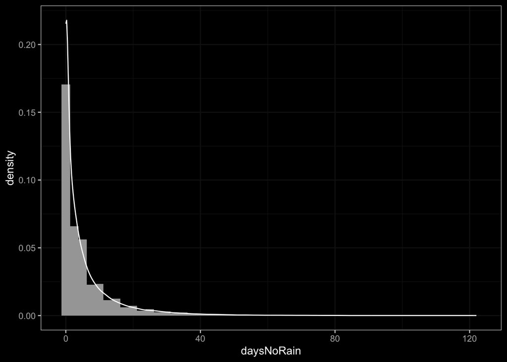

```r
#use ggplot for a histogram with density overlay
NOAA_data %>%
    #we use after_stat to make geom_histogram use density for the y-axis
    ggplot(aes(daysNoRain, after_stat(density))) +
    geom_histogram(bins = 50) +
    geom_density() +
    dark_theme_bw()
```

The 122 days of no rain?! Apparently the summer of 2010. From the 21st of November until the 23rd of March. Wow.

```r
#get max days no rain record (122)
maxDaysNoRain = NOAA_data$daysNoRain %>% max(., na.rm = T)
#get the date of the day with 122 days of no rain i.e the last one
lastDroughtDay = NOAA_data[which(NOAA_data$daysNoRain==maxDaysNoRain),]$DATE %>% as.Date()

#filter and show the dates during the longest no rain period
NOAA_data %>%
    mutate(DATE = as.Date(DATE)) %>%
    filter(DATE < lastDroughtDay+1) %>%
    filter(DATE > (lastDroughtDay-123))
```

| STATION | NAME | LATITUDE | LONGITUDE | ELEVATION | DATE | PRCP | SNWD | TAVG | TMAX | TMIN | Year | Month | Day | did_rain | Month_name | NoRainStreakID | daysNoRain |
| --- | --- | --- | --- | --- | --- | --- | --- | --- | --- | --- | --- | --- | --- | --- | --- | --- | --- |
| ASN00009021 | PERTH AIRPORT, AS | -31.9275 | 115.9764 | 15.4 | 2009-11-20 | 3.8 | NA | 16.2 | 22.0 | 11.9 | 2009 | 11 | 20 | TRUE | November | 10287 | 0 |
| ASN00009021 | PERTH AIRPORT, AS | -31.9275 | 115.9764 | 15.4 | 2009-11-21 | 0.0 | NA | 17.1 | 22.6 | 10.6 | 2009 | 11 | 21 | FALSE | November | 10288 | 1 |
| ASN00009021 | PERTH AIRPORT, AS | -31.9275 | 115.9764 | 15.4 | 2009-11-22 | 0.0 | NA | 19.4 | 27.8 | 11.4 | 2009 | 11 | 22 | FALSE | November | 10288 | 2 |
| ASN00009021 | PERTH AIRPORT, AS | -31.9275 | 115.9764 | 15.4 | 2009-11-23 | 0.0 | NA | 23.8 | 34.3 | 11.2 | 2009 | 11 | 23 | FALSE | November | 10288 | 3 |
| ASN00009021 | PERTH AIRPORT, AS | -31.9275 | 115.9764 | 15.4 | 2009-11-24 | 0.0 | NA | 23.4 | 37.1 | 11.3 | 2009 | 11 | 24 | FALSE | November | 10288 | 4 |
| ASN00009021 | PERTH AIRPORT, AS | -31.9275 | 115.9764 | 15.4 | 2009-11-25 | 0.0 | NA | 17.4 | 24.1 | 10.9 | 2009 | 11 | 25 | FALSE | November | 10288 | 5 |
| ASN00009021 | PERTH AIRPORT, AS | -31.9275 | 115.9764 | 15.4 | 2009-11-26 | 0.0 | NA | 15.7 | 21.6 | 9.8 | 2009 | 11 | 26 | FALSE | November | 10288 | 6 |
| ASN00009021 | PERTH AIRPORT, AS | -31.9275 | 115.9764 | 15.4 | 2009-11-27 | 0.0 | NA | 17.0 | 22.9 | 6.8 | 2009 | 11 | 27 | FALSE | November | 10288 | 7 |
| ASN00009021 | PERTH AIRPORT, AS | -31.9275 | 115.9764 | 15.4 | 2009-11-28 | 0.0 | NA | 21.8 | 31.6 | 9.9 | 2009 | 11 | 28 | FALSE | November | 10288 | 8 |
| ASN00009021 | PERTH AIRPORT, AS | -31.9275 | 115.9764 | 15.4 | 2009-11-29 | 0.0 | NA | 19.8 | 29.7 | 11.6 | 2009 | 11 | 29 | FALSE | November | 10288 | 9 |

[output cut: 113 more lines]

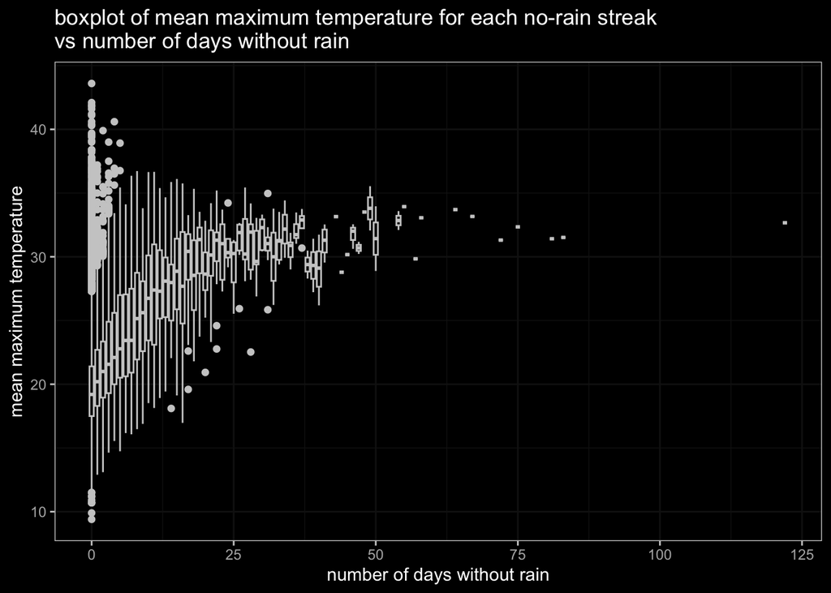

```r
#corr streak length vs TMAX
#inherent bias in precision by number of days...
#and same problem with time of year bias since heat cor with rainfall already
NOAA_data %>%
    #group by rain streak ID
    group_by(NoRainStreakID) %>%
    #get statistics by group
    summarise(
        n = n(),
        length = max(daysNoRain),
        meanTMAX = mean(TMAX, na.rm = T),
    ) %>% drop_na() %>% #nan values where no TMAX recorded
    ggplot(aes(length, meanTMAX, group = length)) +
    geom_boxplot() + #boxplot of meanTMAX for each integer length
    dark_theme_bw() +
    ggtitle("boxplot of mean maximum temperature for each no-rain streak\nvs number of days without rain") +
    ylab("mean maximum temperature") +
    xlab("number of days without rain")
```

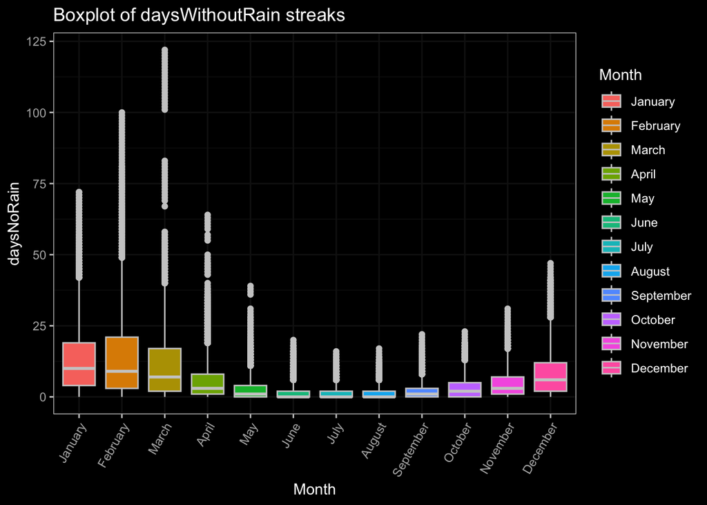

```r
#longer streaks in summer, illustrate
#simplest is just groupby month and do boxplots
NOAA_data %>%
    group_by(NoRainStreakID, Month=Month_name) %>%
    summarise(daysNoRain) %>%
    #because we are doing this by month we remove days over 30 as they bias towards March
    # filter(daysNoRain <=29) %>%
    ggplot(aes(Month, daysNoRain, group = Month, fill = Month)) +
    geom_boxplot() +
    dark_theme_bw() +
    #adjust xlabels to fit
    theme(axis.text.x=element_text(angle=60,hjust=1)) +
    ggtitle("Boxplot of daysWithoutRain streaks ")
```

Here, I have grouped no rain streaks by month (regardless of year) and have then plotted box plots of the number of days of each streak. This gives us a distribution of the no rain streak lengths for each month. We can see that winter months rarely have periods of no rain longer than a few days.

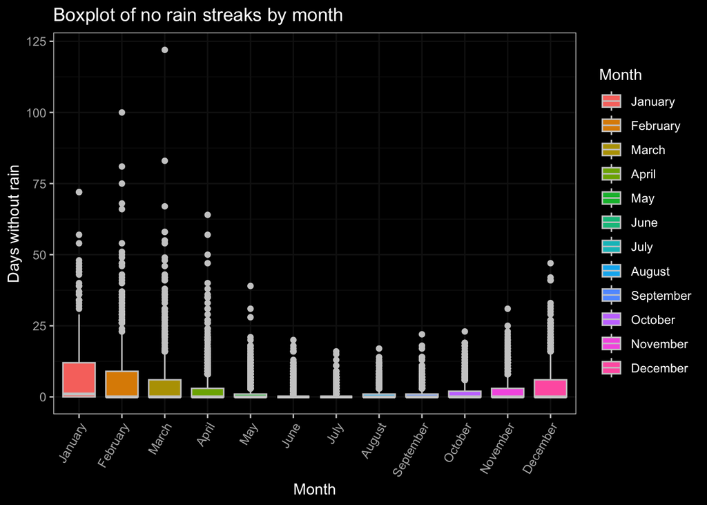

```r
NOAA_data %>%
    #group by rain streak ID, we include Month_name here as a labelling variable
    #Month_name here will mean we include the same streak multiple times if it spills over into the next month
    group_by(NoRainStreakID, Month_name) %>%
    #get statistics by group
    summarise(
        n = n(),
        length = max(daysNoRain),
        meanTMAX = mean(TMAX, na.rm = T),
    ) %>%
    group_by(Month=Month_name) %>%
    summarise(length) %>%
    ggplot(aes(Month, length, group = Month, fill = Month)) +
    geom_boxplot() +
    dark_theme_bw() +
    #adjust xlabels to fit
    theme(axis.text.x=element_text(angle=60,hjust=1)) +
    ggtitle("Boxplot of no rain streaks by month") +
    ylab("Days without rain")
```

Oh boy. We can fairly easily group by Year, and streak ID to get the mean number of days each streak lasts for each year. Similar to rainfall over the years, we see a trend of increasing mean number of days with no rain in a row. Visually we can see this trend is linear. There is an outlier year in 2010 which corresponds to the very long streak of no rain over that year’s summer (starting in November 2009).

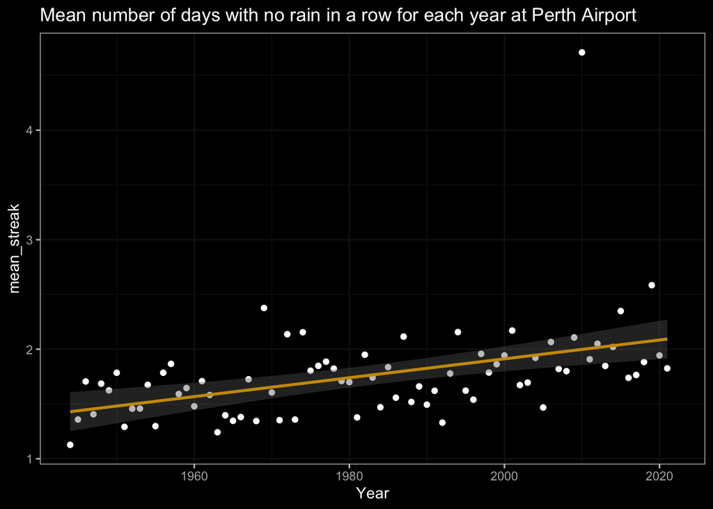

```r
#streak by year are they getting longer?
noRainStreakByYear <- NOAA_data %>%
    group_by(NoRainStreakID, Year) %>%
    #get statistics by group
    summarise(
        n = n(),
        length = max(daysNoRain),
        meanTMAX = mean(TMAX, na.rm = T),
        meanRainfall = mean(PRCP),
    ) %>%
    group_by(Year) %>%
    summarise(
        longest_streak = max(length),
        mean_streak = mean(length)
    )
noRainStreakByYear %>% ggplot(aes(Year, mean_streak)) +
    geom_point() +
    geom_smooth(method="lm") +
    dark_theme_bw() +
    ggtitle("Mean number of days with no rain in a row for each year at Perth Airport")
```

```r
noRainStreakByYear.Model <- lm(mean_streak ~ Year, data = noRainStreakByYear)
broom::tidy(summary(noRainStreakByYear.Model))
```

| term | estimate | std.error | statistic | p.value |
| --- | --- | --- | --- | --- |
| (Intercept) | -15.322184132 | 3.977970200 | -3.851759 | 2.430554e-04 |
| Year | 0.008617189 | 0.002006413 | 4.294823 | 5.107743e-05 |